# Práctica Métodos Supervisados

Francisco Javier Gómez Sánchez

17/12/2020

# Descripción del problema

Para el proyecto de la asignatura, he decidido escoger el dataset de enfermedades de corazón (‘*heart diseases*’) de la Universidad de California, Irvine (UCI). El objetivo es predecir, a partir de una serie de características, si hay una enfermedad cardíaca o no. Originalmente, la clase a predecir estaba comprendida entre los valores 0 y 4, puesto que se predecían varios tipos de cardiopatía. Sin embargo, se simplificó el problema para detectar si existe una enfermedad de corazón o no. Es decir, estamos ante un problema de clasificación binaria.

He escogido este dataset porque la investigación en medicina supone un gran avance para mejorar la vida de las personas.

Respecto a los algoritmos que escogidos para resolver el problema, serán los siguientes:

- Stochastic Gradient Boosting
- Neural Network
- Random Forest

Como métrica principal de comparación de los modelos, uso MAE. Los modelos predicen la salida entre 0 y 1, por lo que se puede calcular con esta métrica la distancia entre la predicción y el valor real (0 ó 1). Además, se verán otras métricas en el resumen de los modelos, como son RMSE o Kappa.

El dataset original consta de 76 atributos, pero todas las investigaciones publicadas usan un subset de 14 de ellos. Por tanto, se va a trabajar con el mismo subset que han utilizado los investigadores. A continuación, una tabla con los atributos del dataset.

[output not shown]

# Análisis de las variables

Con la función glimpse se pueden ver algunos valores que toman las variables del dataset.

```r
data <- read.csv(file = 'heart.csv')
colnames(data) <- c("age", "sex", "cp", "trestbps", "chol", "fbs", "restecg",
                    "thalach", "exang", "oldpeak", "slope", "ca", "thal",
                    "target")
glimpse(data)
```

```
## Rows: 303
## Columns: 14
## $ age      <int> 63, 37, 41, 56, 57, 57, 56, 44, 52, 57, 54, 48, 49, 64, 58...
## $ sex      <int> 1, 1, 0, 1, 0, 1, 0, 1, 1, 1, 1, 0, 1, 1, 0, 0, 0, 0, 1, 0...
## $ cp       <int> 3, 2, 1, 1, 0, 0, 1, 1, 2, 2, 0, 2, 1, 3, 3, 2, 2, 3, 0, 3...
## $ trestbps <int> 145, 130, 130, 120, 120, 140, 140, 120, 172, 150, 140, 130...
## $ chol     <int> 233, 250, 204, 236, 354, 192, 294, 263, 199, 168, 239, 275...
## $ fbs      <int> 1, 0, 0, 0, 0, 0, 0, 0, 1, 0, 0, 0, 0, 0, 1, 0, 0, 0, 0, 0...
## $ restecg  <int> 0, 1, 0, 1, 1, 1, 0, 1, 1, 1, 1, 1, 1, 0, 0, 1, 1, 1, 1, 1...
## $ thalach  <int> 150, 187, 172, 178, 163, 148, 153, 173, 162, 174, 160, 139...
## $ exang    <int> 0, 0, 0, 0, 1, 0, 0, 0, 0, 0, 0, 0, 0, 1, 0, 0, 0, 0, 0, 0...
## $ oldpeak  <dbl> 2.3, 3.5, 1.4, 0.8, 0.6, 0.4, 1.3, 0.0, 0.5, 1.6, 1.2, 0.2...
## $ slope    <int> 0, 0, 2, 2, 2, 1, 1, 2, 2, 2, 2, 2, 2, 1, 2, 1, 2, 0, 2, 2...
## $ ca       <int> 0, 0, 0, 0, 0, 0, 0, 0, 0, 0, 0, 0, 0, 0, 0, 0, 0, 0, 0, 2...
## $ thal     <int> 1, 2, 2, 2, 2, 1, 2, 3, 3, 2, 2, 2, 2, 2, 2, 2, 2, 2, 2, 2...
## $ target   <int> 1, 1, 1, 1, 1, 1, 1, 1, 1, 1, 1, 1, 1, 1, 1, 1, 1, 1, 1, 1...
```

Ahora se procede a analizar las distintas variables del conjunto de datos.

## Variable a predecir

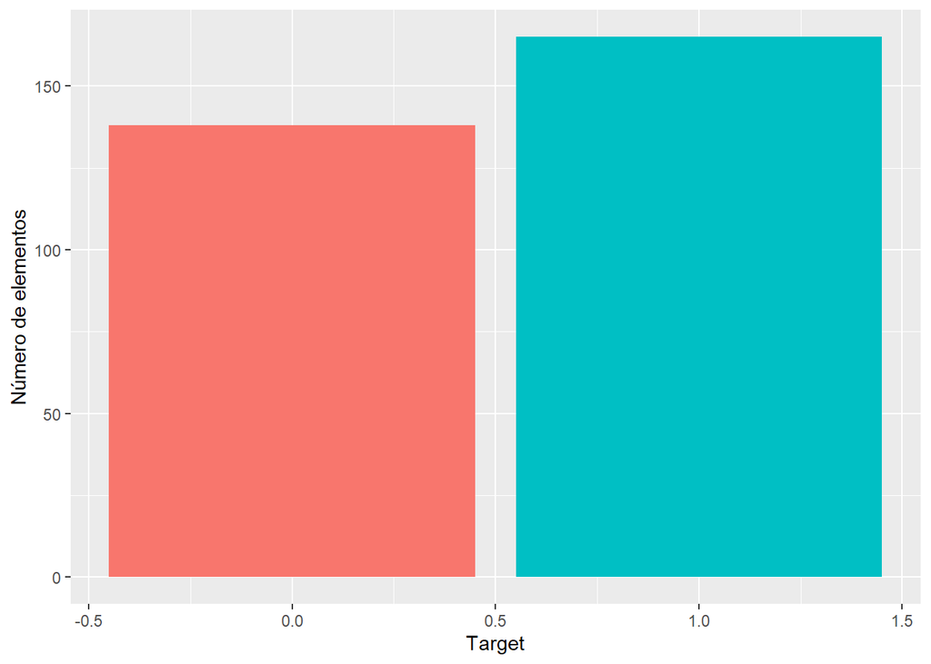

```r
ggplot(data,aes(target,fill=as.factor(target)))+
    geom_bar(stat="count")+
    guides(fill=F)+
    labs(x="Target", y="Número de elementos")
```

Como podemos ver, la clase a predecir no presenta un signo de desbalanceo.

## Variable age

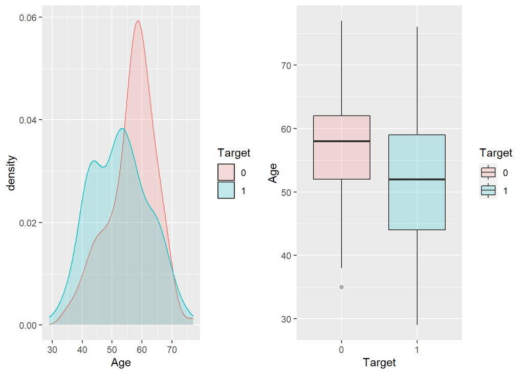

```r
g1 <- ggplot(data,aes(age,col=as.factor(target),fill=as.factor(target)))+
  geom_density(alpha=0.2)+
  guides(col=F)+
  labs(fill="Target",x="Age")

g2 <- ggplot(data,aes(as.factor(target),age,fill=as.factor(target)))+
  geom_boxplot(alpha=0.2)+
  labs(y="Age",x="Target",fill="Target")

grid.arrange(g1, g2, ncol=2)
```

Se puede apreciar que las personas que sufren del corazón presentan una distribución distinta a las personas que no padecen ninguna enfermedad.

A continuación. un gráfico con la distribución de la frecuencia de la los valores en formato diagrama de barras.

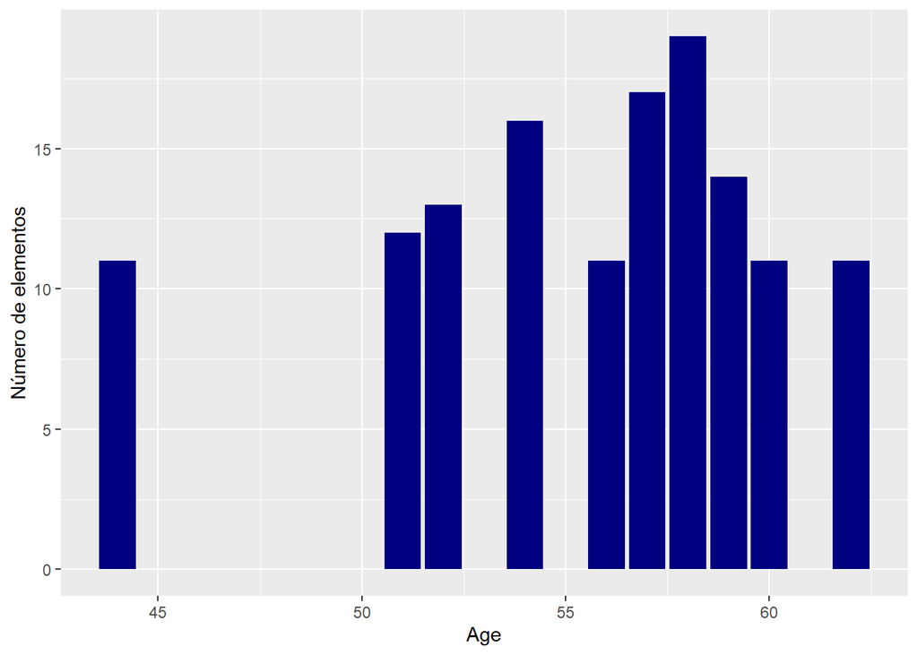

```r
data %>%
  group_by(age) %>%
  count() %>%
  filter(n > 10) %>%
  ggplot()+
  geom_col(aes(age, n), fill = "navyblue")+
  xlab("Age")  +
  ylab("Número de elementos")
```

## Variable sex

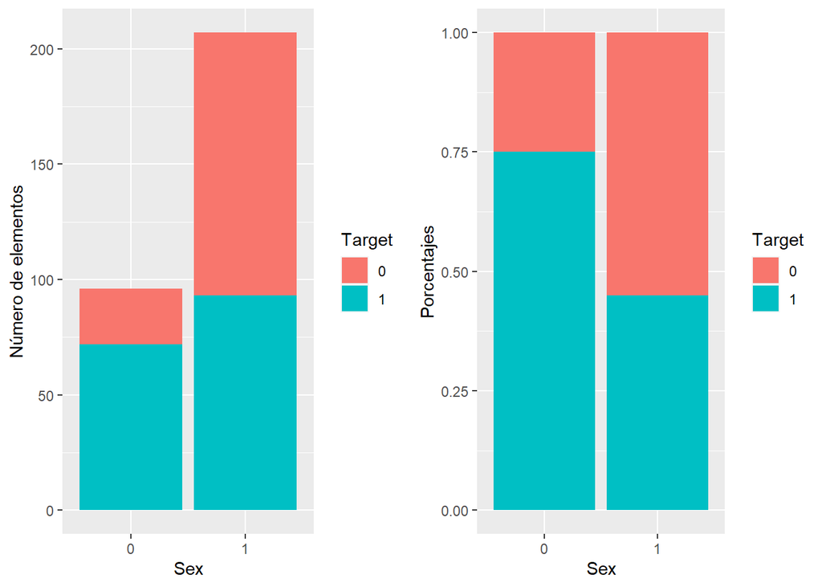

```r
g1 <- ggplot(data,aes(as.factor(sex),fill=as.factor(target)))+
     geom_bar(stat="count")+
     labs(x="Sex",fill="Target", y="Número de elementos")
g2 <- ggplot(data,aes(as.factor(sex),fill=as.factor(target)))+
     geom_bar(stat="count",position="fill")+
     labs(x="Sex",fill="Target",y="Porcentajes")

grid.arrange(g1, g2, ncol=2)
```

## Variable cp

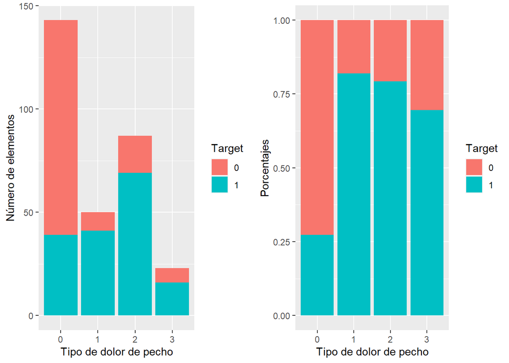

```r
g1 <- ggplot(data,aes(as.factor(cp),fill=as.factor(target)))+
  geom_bar(stat="count")+
  labs(x="Tipo de dolor de pecho", fill="Target", y="Número de elementos" )

g2 <- ggplot(data,aes(as.factor(cp),fill=as.factor(target)))+
  geom_bar(stat="count",position="fill")+
  labs(x="Tipo de dolor de pecho",fill="Target",y="Porcentajes")

grid.arrange(g1, g2, ncol=2)
```

## Variable trestbps

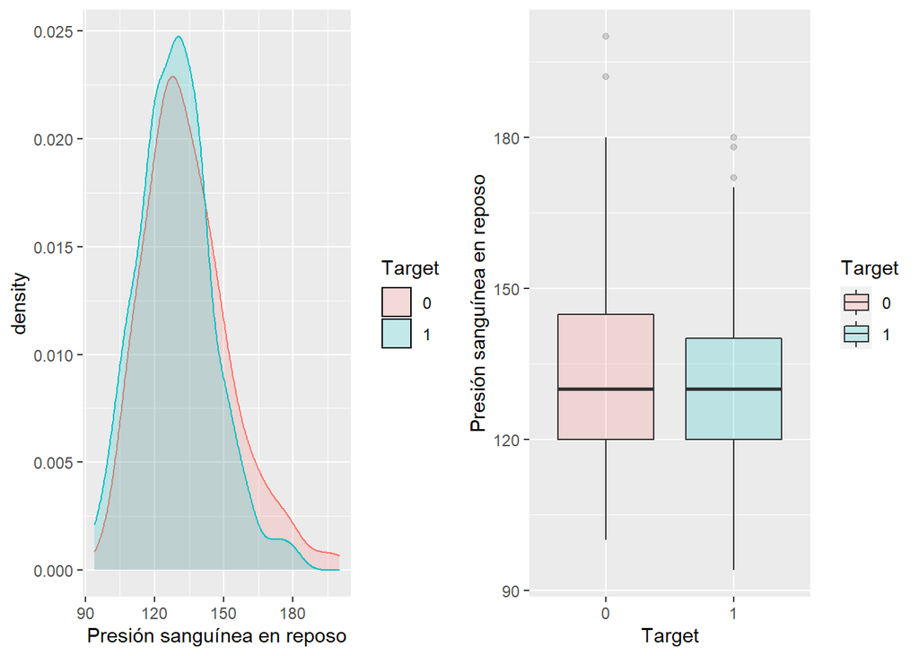

```r
g1 <- ggplot(data,aes(trestbps,col=as.factor(target),fill=as.factor(target)))+
  geom_density(alpha=0.2)+
  guides(col=F)+
  labs(fill="Target",x="Presión sanguínea en reposo")

g2 <- ggplot(data,aes(as.factor(target),trestbps,fill=as.factor(target)))+
  geom_boxplot(alpha=0.2)+
  labs(y="Presión sanguínea en reposo",x="Target",fill="Target")

grid.arrange(g1, g2, ncol=2)
```

## Variable chol

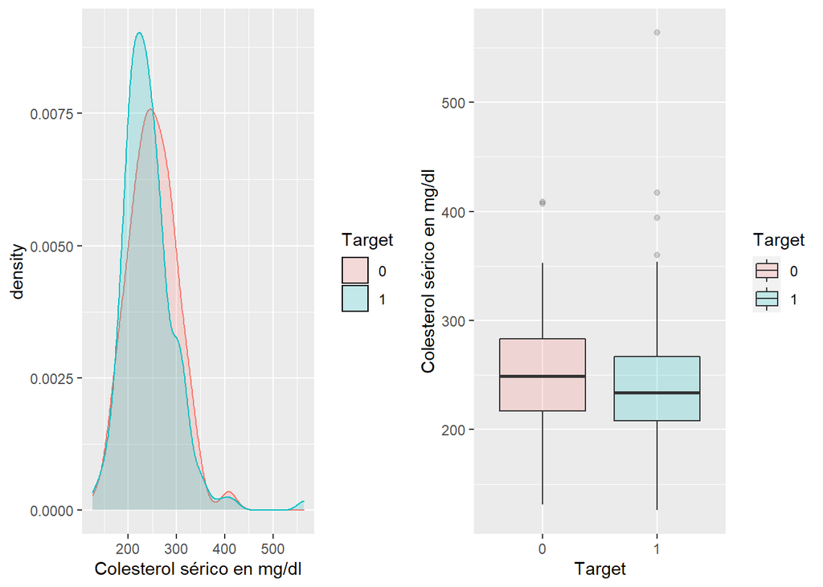

```r
g1 <- ggplot(data,aes(chol,col=as.factor(target),fill=as.factor(target)))+
  geom_density(alpha=0.2)+
  guides(col=F)+
  labs(fill="Target",x="Colesterol sérico en mg/dl")

g2 <- ggplot(data,aes(as.factor(target),chol,fill=as.factor(target)))+
  geom_boxplot(alpha=0.2)+
  labs(y="Colesterol sérico en mg/dl",x="Target",fill="Target")

grid.arrange(g1, g2, ncol=2)
```

Representación de los niveles de colesterol por edad y sexo.

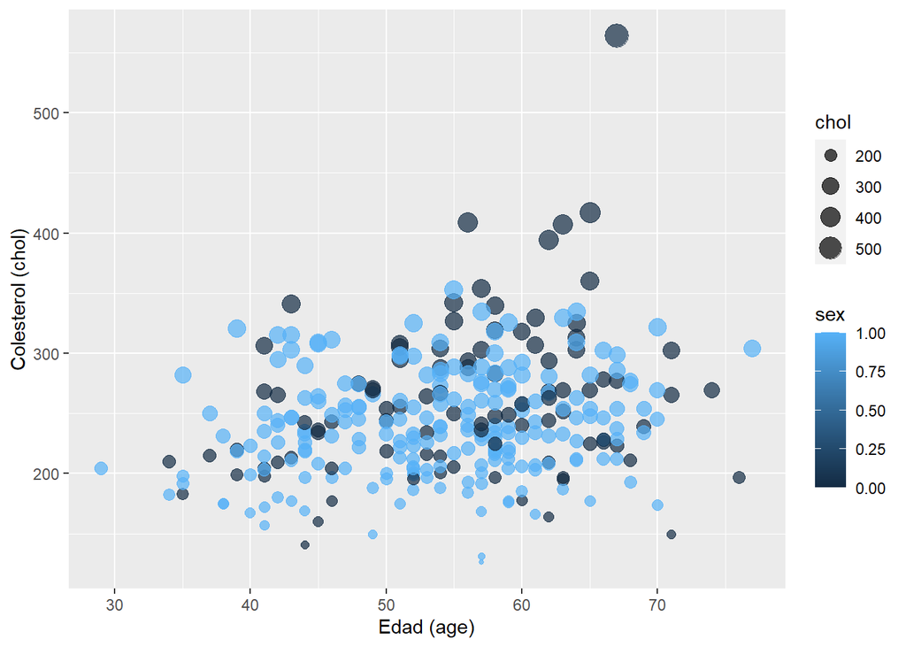

```r
data %>%
  ggplot(aes(x=age,y=chol,color=sex, size=chol))+
  geom_point(alpha=0.7)+xlab("Edad (age)") +
  ylab("Colesterol (chol)")+
  guides(fill = guide_legend(title = "Gender"))
```

## Variable fbs

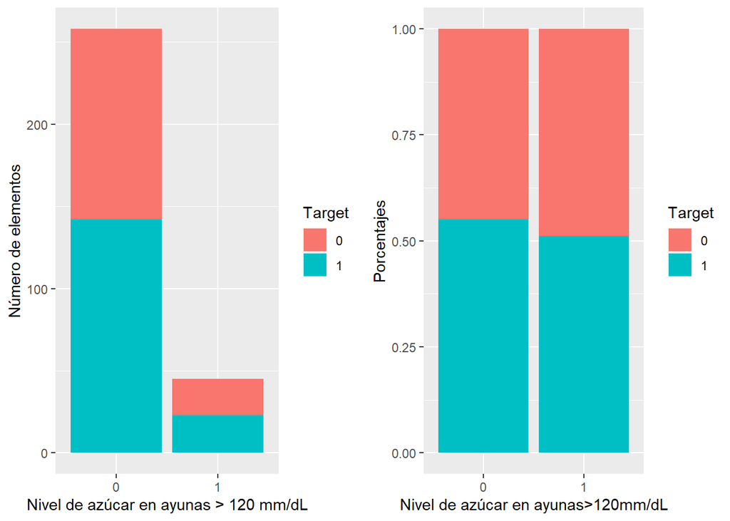

```r
g1 <- ggplot(data,aes(as.factor(fbs),fill=as.factor(target)))+
  geom_bar(stat="count")+
  labs(x="Nivel de azúcar en ayunas > 120 mm/dL", y="Número de elementos",
       fill="Target")

g2 <- ggplot(data,aes(as.factor(fbs),fill=as.factor(target)))+
  geom_bar(stat="count",position="fill")+
  labs(x="Nivel de azúcar en ayunas>120mm/dL",fill="Target",y="Porcentajes")

grid.arrange(g1, g2, ncol=2)
```

## Variable restecg

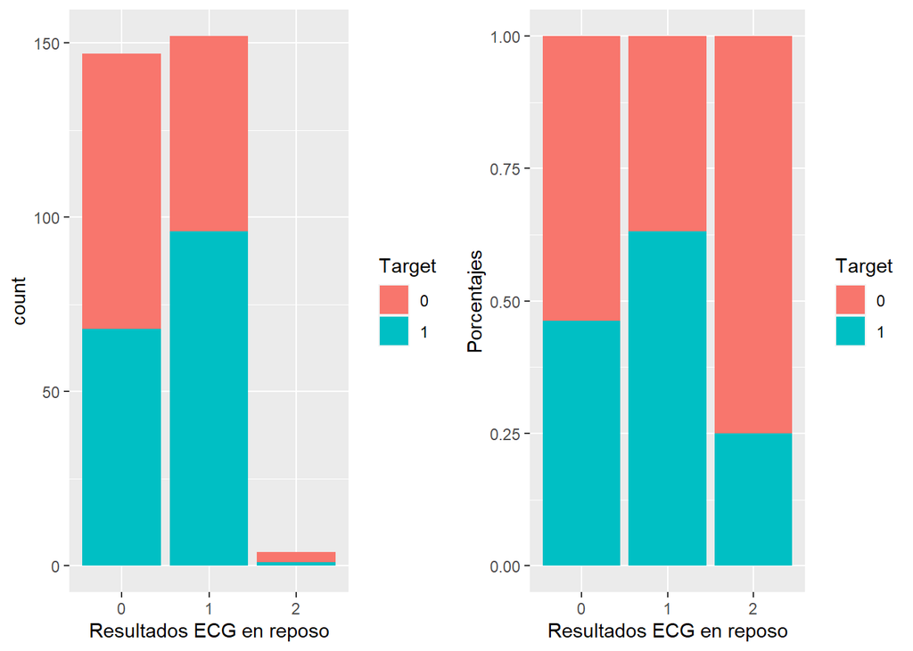

```r
g1 <- ggplot(data,aes(as.factor(restecg),fill=as.factor(target)))+
  geom_bar(stat="count")+
  labs(x="Resultados ECG en reposo",x="Número de elementos",fill="Target")

g2 <- ggplot(data,aes(as.factor(restecg),fill=as.factor(target)))+
  geom_bar(stat="count",position="fill")+
  labs(x="Resultados ECG en reposo",fill="Target",y="Porcentajes")

grid.arrange(g1, g2, ncol=2)
```

## Variable thalch

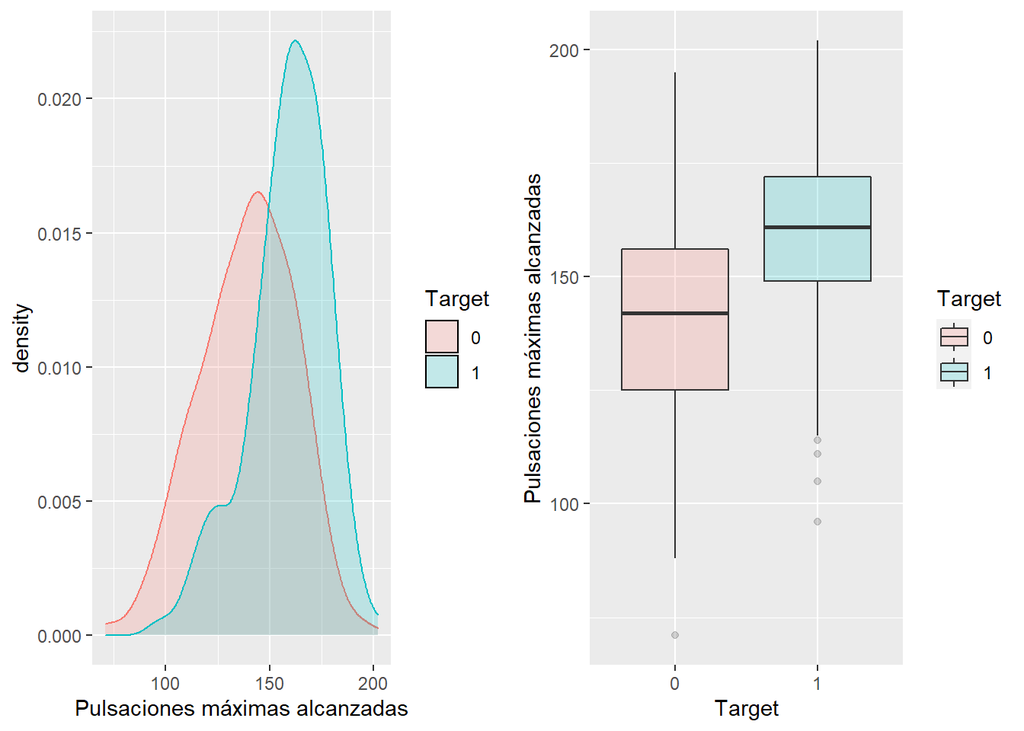

```r
g1 <-  ggplot(data,aes(thalach,col=as.factor(target),fill=as.factor(target)))+
  geom_density(alpha=0.2)+
  guides(col=F)+
  labs(fill="Target",x="Pulsaciones máximas alcanzadas")

g2 <- ggplot(data,aes(as.factor(target),thalach,fill=as.factor(target)))+
  geom_boxplot(alpha=0.2)+
  labs(y="Pulsaciones máximas alcanzadas",x="Target",fill="Target")

grid.arrange(g1, g2, ncol=2)
```

## Variable exang

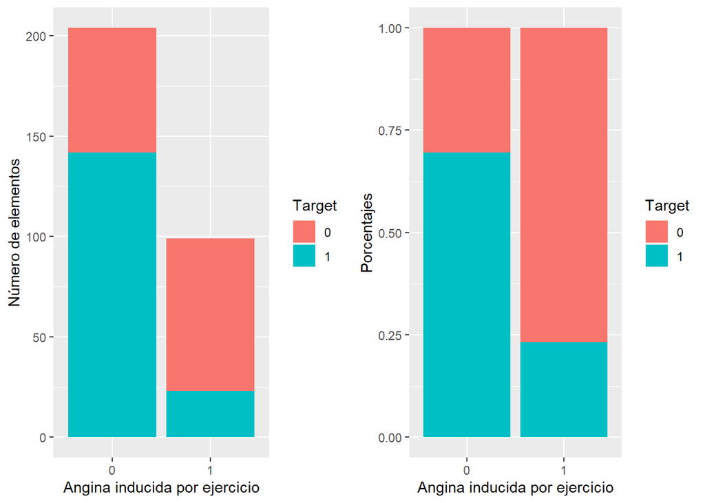

```r
g1 <- ggplot(data,aes(as.factor(exang),fill=as.factor(target)))+
  geom_bar(stat="count")+
  labs(x="Angina inducida por ejercicio",y="Número de elementos",fill= "Target")

g2 <- ggplot(data,aes(as.factor(exang),fill=as.factor(target)))+
  geom_bar(stat="count",position="fill")+
  labs(x="Angina inducida por ejercicio",fill="Target",y="Porcentajes")

grid.arrange(g1, g2, ncol=2)
```

## Variable oldpeak

[figure not shown]

```r
g1 <- ggplot(data,aes(oldpeak,col=as.factor(target),fill=as.factor(target)))+
  geom_density(alpha=0.2)+
  guides(col=F)+
  labs(fill="Target",x="Depresión onda ST inducida por el ejercicio respecto
       al reposo")

g2 <- ggplot(data,aes(as.factor(target),thalach,fill=as.factor(target)))+
  geom_boxplot(alpha=0.2)+
  labs(y="Depresión onda ST inducida por el ejercicio respecto al reposo",
       x="Target",fill="Target")

grid.arrange(g1, g2, ncol=2)
```

## Variable slope

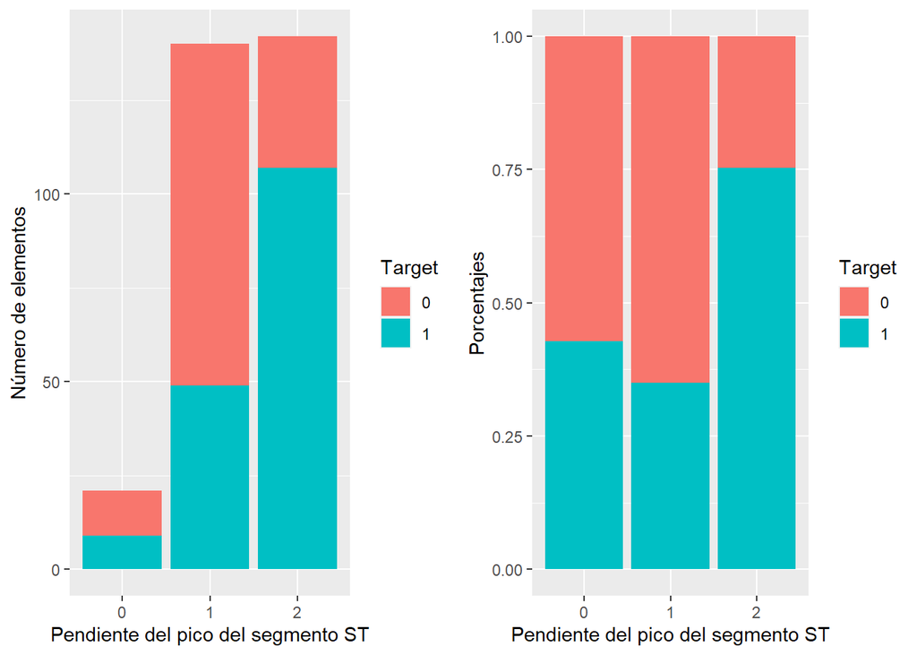

```r
g1 <- ggplot(data,aes(as.factor(slope),fill=as.factor(target)))+
  geom_bar(stat="count")+
  labs(x="Pendiente del pico del segmento ST",y="Número de elementos",
       fill="Target")

g2 <- ggplot(data,aes(as.factor(slope),fill=as.factor(target)))+
  geom_bar(stat="count",position="fill")+
  labs(x="Pendiente del pico del segmento ST",fill="Target",y="Porcentajes")

grid.arrange(g1, g2, ncol=2)
```

## Variable ca

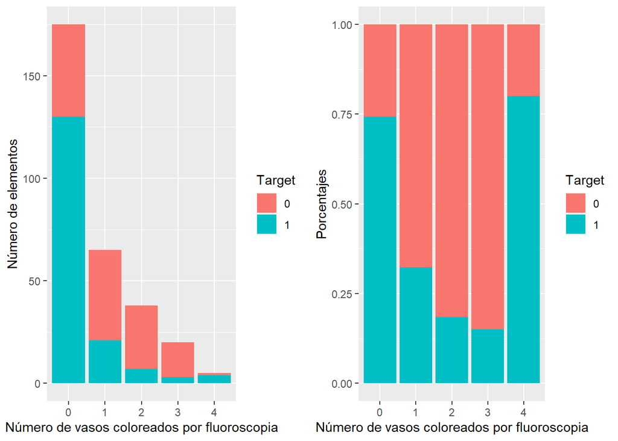

```r
g1 <- ggplot(data,aes(as.factor(ca),fill=as.factor(target)))+
  geom_bar(stat="count")+
  labs(x="Número de vasos coloreados por fluoroscopia",y="Número de elementos",
       fill="Target")

g2 <- ggplot(data,aes(as.factor(ca),fill=as.factor(target)))+
  geom_bar(stat="count",position="fill")+
  labs(x="Número de vasos coloreados por fluoroscopia",fill="Target",
       y="Porcentajes")

grid.arrange(g1, g2, ncol=2)
```

## Variable thal

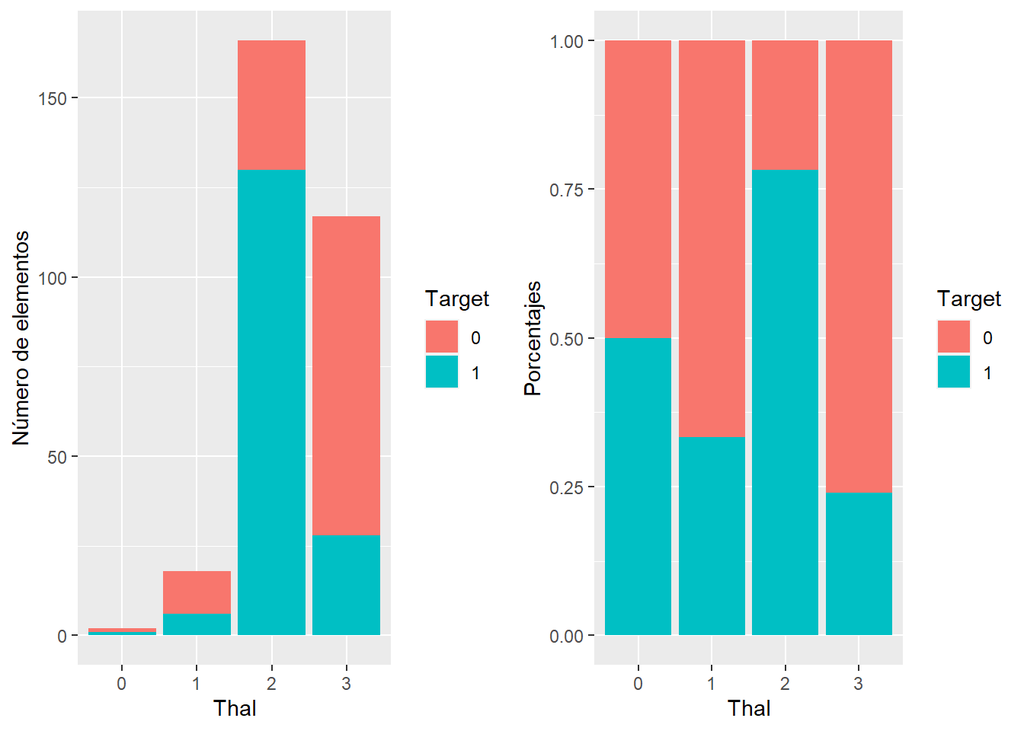

```r
g1 <- ggplot(data,aes(as.factor(thal),fill=as.factor(target)))+
  geom_bar(stat="count")+
  labs(x="Thal",y="Número de elementos",fill="Target")

g2 <- ggplot(data,aes(as.factor(thal),fill=as.factor(target)))+
  geom_bar(stat="count",position="fill")+
  labs(x="Thal",fill="Target",y="Porcentajes")

grid.arrange(g1,g2,ncol=2)
```

## Correlaciones entre variables

Una vez ploteadas las distribuciones de las variables del dataset, se procede a evaluar la relación que hay entre algunas de ellas.

Comparación entre el colesterol y el tipo de dolor de pecho.

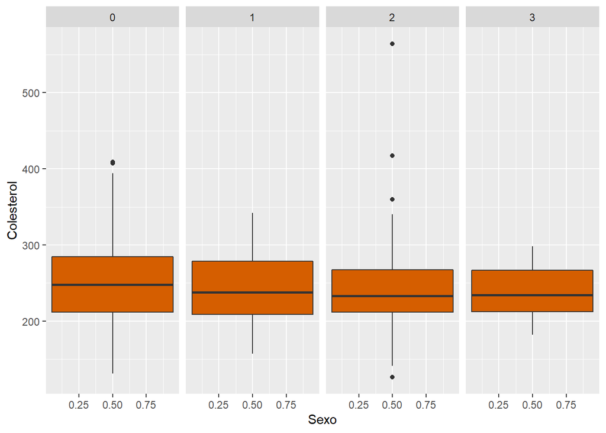

```r
data %>%
  ggplot(aes(x=sex,y=chol))+
  geom_boxplot(fill="#D55E00")+
  xlab("Sexo")+
  ylab("Colesterol")+
  facet_grid(~cp)
```

Relación entre la presión sanguínea y el tipo de dolor de pecho.

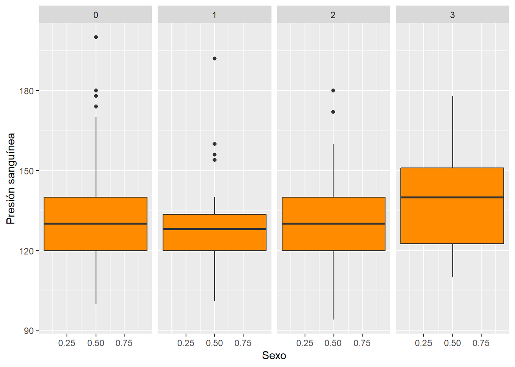

```r
data %>%
  ggplot(aes(x=sex,y=trestbps))+
  geom_boxplot(fill="darkorange")+
  xlab("Sexo")+
  ylab("Presión sanguínea")+
  facet_grid(~cp)
```

Tabla de correlaciones.

```r
cor_heart <- cor(data[,1:13])
```

Se calcula también una tabla gráfica que nos muestre la relación que existe entre las variables.

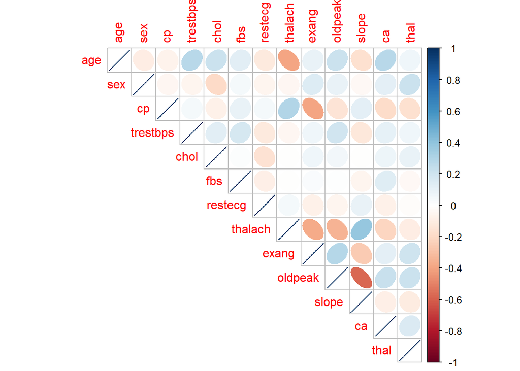

```r
corrplot(cor_heart, method = "ellipse", type="upper",)
```

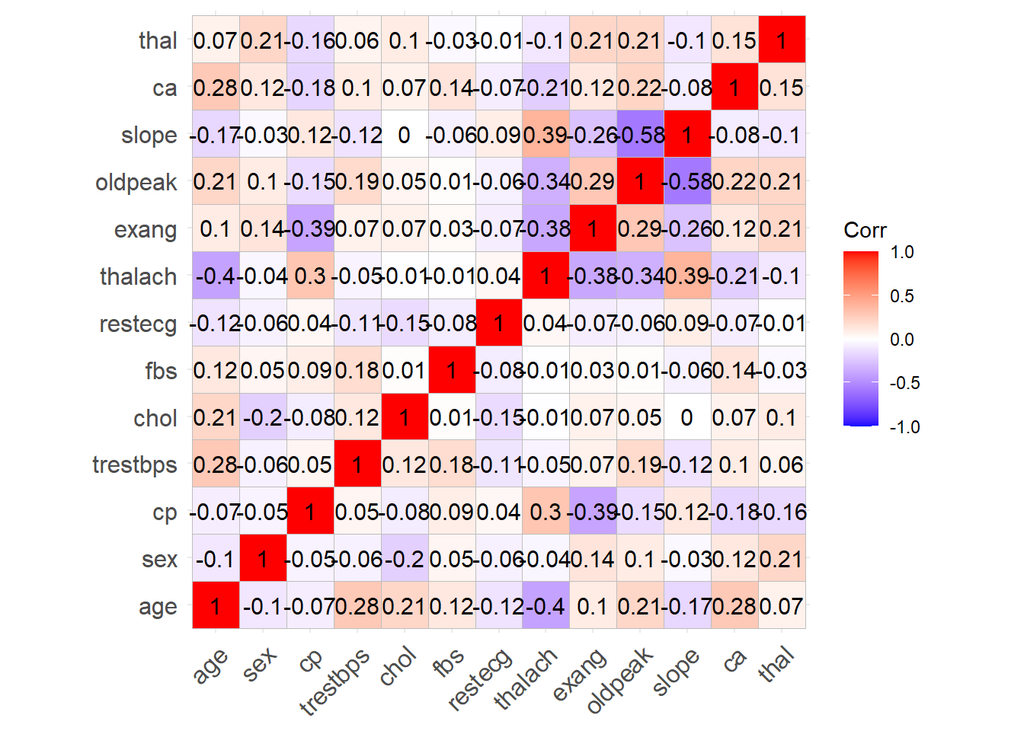

```r
ggcorrplot(cor_heart,lab = T)
```

# Resumen de estadísticas

Con la función summary podemos ver un resumen de los valores de las variables que nos pueden orientar sobre su escala.

```r
summary(data)
```

```
##       age             sex               cp           trestbps
##  Min.   :29.00   Min.   :0.0000   Min.   :0.000   Min.   : 94.0
##  1st Qu.:47.50   1st Qu.:0.0000   1st Qu.:0.000   1st Qu.:120.0
##  Median :55.00   Median :1.0000   Median :1.000   Median :130.0
##  Mean   :54.37   Mean   :0.6832   Mean   :0.967   Mean   :131.6
##  3rd Qu.:61.00   3rd Qu.:1.0000   3rd Qu.:2.000   3rd Qu.:140.0
##  Max.   :77.00   Max.   :1.0000   Max.   :3.000   Max.   :200.0
##       chol            fbs            restecg          thalach
##  Min.   :126.0   Min.   :0.0000   Min.   :0.0000   Min.   : 71.0
##  1st Qu.:211.0   1st Qu.:0.0000   1st Qu.:0.0000   1st Qu.:133.5
##  Median :240.0   Median :0.0000   Median :1.0000   Median :153.0
##  Mean   :246.3   Mean   :0.1485   Mean   :0.5281   Mean   :149.6
##  3rd Qu.:274.5   3rd Qu.:0.0000   3rd Qu.:1.0000   3rd Qu.:166.0
##  Max.   :564.0   Max.   :1.0000   Max.   :2.0000   Max.   :202.0
##      exang           oldpeak         slope             ca
##  Min.   :0.0000   Min.   :0.00   Min.   :0.000   Min.   :0.0000
##  1st Qu.:0.0000   1st Qu.:0.00   1st Qu.:1.000   1st Qu.:0.0000
##  Median :0.0000   Median :0.80   Median :1.000   Median :0.0000
##  Mean   :0.3267   Mean   :1.04   Mean   :1.399   Mean   :0.7294
##  3rd Qu.:1.0000   3rd Qu.:1.60   3rd Qu.:2.000   3rd Qu.:1.0000
##  Max.   :1.0000   Max.   :6.20   Max.   :2.000   Max.   :4.0000
##       thal           target
##  Min.   :0.000   Min.   :0.0000
##  1st Qu.:2.000   1st Qu.:0.0000
##  Median :2.000   Median :1.0000
##  Mean   :2.314   Mean   :0.5446
##  3rd Qu.:3.000   3rd Qu.:1.0000
##  Max.   :3.000   Max.   :1.0000
```

# Feature Selection

Se crea una matriz de correlación a partir de los atributos y se identifican los que son altamente correlacionados. Por lo general, se desea eliminar atributos con una correlación absoluta de 0,75 o superior.

```r
correlationMatrix <- cor(data[,1:13])
print(correlationMatrix)
```

```
##                  age         sex          cp    trestbps         chol
## age       1.00000000 -0.09844660 -0.06865302  0.27935091  0.213677957
## sex      -0.09844660  1.00000000 -0.04935288 -0.05676882 -0.197912174
## cp       -0.06865302 -0.04935288  1.00000000  0.04760776 -0.076904391
## trestbps  0.27935091 -0.05676882  0.04760776  1.00000000  0.123174207
## chol      0.21367796 -0.19791217 -0.07690439  0.12317421  1.000000000
## fbs       0.12130765  0.04503179  0.09444403  0.17753054  0.013293602
## restecg  -0.11621090 -0.05819627  0.04442059 -0.11410279 -0.151040078
## thalach  -0.39852194 -0.04401991  0.29576212 -0.04669773 -0.009939839
## exang     0.09680083  0.14166381 -0.39428027  0.06761612  0.067022783
## oldpeak   0.21001257  0.09609288 -0.14923016  0.19321647  0.053951920
## slope    -0.16881424 -0.03071057  0.11971659 -0.12147458 -0.004037770
## ca        0.27632624  0.11826141 -0.18105303  0.10138899  0.070510925
## thal      0.06800138  0.21004110 -0.16173557  0.06220989  0.098802993
##                   fbs     restecg      thalach       exang      oldpeak
## age       0.121307648 -0.11621090 -0.398521938  0.09680083  0.210012567
## sex       0.045031789 -0.05819627 -0.044019908  0.14166381  0.096092877
## cp        0.094444035  0.04442059  0.295762125 -0.39428027 -0.149230158
## trestbps  0.177530542 -0.11410279 -0.046697728  0.06761612  0.193216472
## chol      0.013293602 -0.15104008 -0.009939839  0.06702278  0.053951920
## fbs       1.000000000 -0.08418905 -0.008567107  0.02566515  0.005747223
## restecg  -0.084189054  1.00000000  0.044123444 -0.07073286 -0.058770226
## thalach  -0.008567107  0.04412344  1.000000000 -0.37881209 -0.344186948
## exang     0.025665147 -0.07073286 -0.378812094  1.00000000  0.288222808
## oldpeak   0.005747223 -0.05877023 -0.344186948  0.28822281  1.000000000
## slope    -0.059894178  0.09304482  0.386784410 -0.25774837 -0.577536817
## ca        0.137979327 -0.07204243 -0.213176928  0.11573938  0.222682322
## thal     -0.032019339 -0.01198140 -0.096439132  0.20675379  0.210244126
##                slope          ca        thal
## age      -0.16881424  0.27632624  0.06800138
## sex      -0.03071057  0.11826141  0.21004110
## cp        0.11971659 -0.18105303 -0.16173557
## trestbps -0.12147458  0.10138899  0.06220989
## chol     -0.00403777  0.07051093  0.09880299
## fbs      -0.05989418  0.13797933 -0.03201934
## restecg   0.09304482 -0.07204243 -0.01198140
## thalach   0.38678441 -0.21317693 -0.09643913
## exang    -0.25774837  0.11573938  0.20675379
## oldpeak  -0.57753682  0.22268232  0.21024413
## slope     1.00000000 -0.08015521 -0.10476379
## ca       -0.08015521  1.00000000  0.15183213
## thal     -0.10476379  0.15183213  1.00000000
```

```r
# encontrar los atributos altamente correlados (>0.75)
highlyCorrelated <- findCorrelation(correlationMatrix, cutoff=0.75)
# índices de los atributos altamente correlados
print(highlyCorrelated)
```

```
## integer(0)
```

No se encuentran parámetros altamente correlados.

# Feature extraction. Principal Component Analysis (PCA)

Es interesante ver si se puede encontrar una relación lineal entre las variables que describen los datos pero con una dimensionalidad menor. Para ello usamos el método PCA.

Los datos se escalan sustrayendoles la media de su columna y se escalan a la desviación estándar.

```r
pca <- prcomp(data[,1:13], center = TRUE, scale = TRUE)
```

```r
summary(pca)
```

```
## Importance of components:
##                           PC1    PC2     PC3     PC4     PC5     PC6     PC7
## Standard deviation     1.6622 1.2396 1.10582 1.08681 1.01092 0.98489 0.92885
## Proportion of Variance 0.2125 0.1182 0.09406 0.09086 0.07861 0.07462 0.06637
## Cumulative Proportion  0.2125 0.3307 0.42481 0.51567 0.59428 0.66890 0.73527
##                            PC8    PC9    PC10    PC11    PC12   PC13
## Standard deviation     0.88088 0.8479 0.78840 0.72808 0.65049 0.6098
## Proportion of Variance 0.05969 0.0553 0.04781 0.04078 0.03255 0.0286
## Cumulative Proportion  0.79495 0.8503 0.89807 0.93885 0.97140 1.0000
```

Se va a plotear la varianza de las componentes principales calculadas.

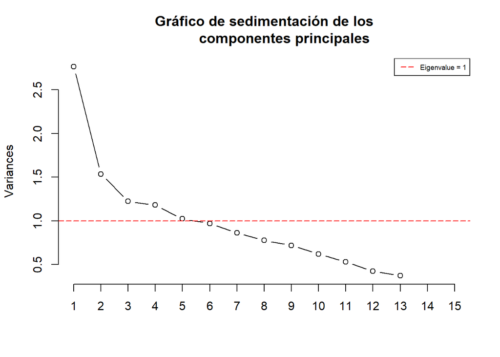

```r
screeplot(pca, type = "l", npcs = 15, main = "Gráfico de sedimentación de los
          componentes principales")
abline(h = 1, col="red", lty=5)
legend("topright", legend=c("Eigenvalue = 1"), col=c("red"), lty=5, cex=0.6)
```

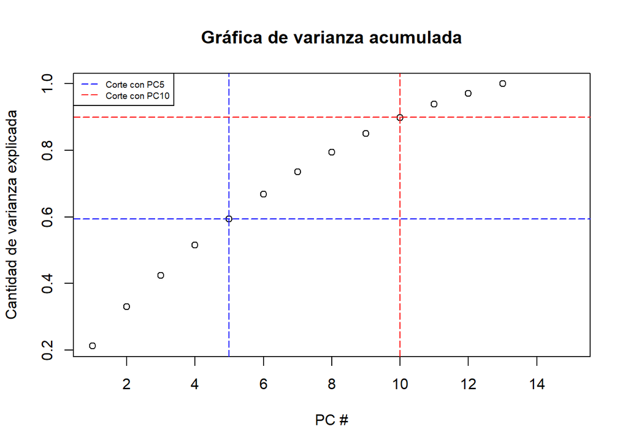

```r
cumpro <- cumsum(pca$sdev^2 / sum(pca$sdev^2))
plot(cumpro[0:15], xlab = "PC #", ylab = "Cantidad de varianza explicada",
     main = "Gráfica de varianza acumulada")
abline(v = 5, col="blue", lty=5)
abline(h = 0.594, col="blue", lty=5)
abline(v = 10, col="red", lty=5)
abline(h = 0.9, col="red", lty=5)
legend("topleft", legend=c("Corte con PC5", "Corte con PC10"),
      col=c("blue", "red"), lty=5, cex=0.6)
```

Como se aprecia, aunque los 5 primeros componentes tienen un autovalor mayor a 1, su varianza acumulada es inferior al 60% , por lo que perderíamos mucha información si usasemos esas componentes como variables para representar el dataset completo. Para perder únicamente una varianza del 10% debemos de usar los 10 primeros componentes principales del PCA. Reducir la dimensionalidad de 13 a 10 variables no parece un gran avance, por lo que trabajaremos con las variables originales y así mantener toda la información de los datos.

A continuación se muestran las 2 primeras componentes del análisis PCA.

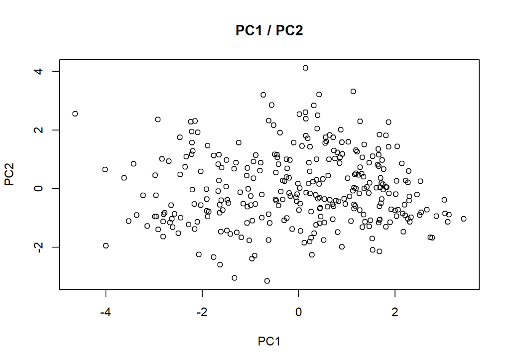

```r
plot(pca$x[,1],pca$x[,2], xlab="PC1", ylab = "PC2", main = "PC1 / PC2")
```

No se aprecia ninguna correlación entre las 2 variables principales.

# Training y test dataset

En primer lugar, vamos a reordenar los datos para que aparezcan de la manera más aleatoria posible y evitar que todos los datos de una clase estén contenidos en su mayoría en uno de los datasets de training o testing.

```r
set.seed(107)
rows_rand <- sample(nrow(data))
```

```r
data_s <- data[rows_rand, ]
inTrain <- createDataPartition(y=data_s$target, p=.8, list=FALSE)
training <- data_s[inTrain,]
testing <- data_s[-inTrain,]
```

Se pueden utilizar otras funciones como CreateFolds() y createResample(). La última se puede utilizar para crear muestras mediante bootstrap y la primera se puede utilizar para generar agrupaciones de validación cruzada equilibradas a partir del conjunto de datos.

# Modelos

En primer lugar, se crean las opciones de control, que van a ser las mismas para todos los modelos. Utilizo validación cruzada (se entrenan k modelos distintos, cada uno entrenado con todos los datos de entrenamiento excepto con una 1/k parte de los datos, usada para validarlos y distinta para cada uno de los k modelos). He escogido k=10.

```r
fitControl <- trainControl(## 10-fold CV
    method = "repeatedcv",
    number = 10,
    ## repeated ten times
    repeats = 10)
```

Se pueden escoger otros métodos de control (con el parámetro method) aparte de la validación cruzada. Entre los otros métodos disponibles tenemos bootstrap (“boot”) o validación cruzada tipo leave-one-out o jacknife (“LOOCV”).

En la función de control también podemos controlar el número de divisiones (k) de la validación cruzada (number) o el número de modelos que se van a entrenar (repeats).

## tuneLength y tuneGrid

El parámetro tuneLength define el número total de combinaciones de parámetros que se evaluarán. Se va a usar esta estrategia para el entrenamiento de los modelos de neural network.

El parámetro tuneGrid nos permite decidir qué valores tomarán los parámetros, mientras que tuneLength solo limita el número de parámetros predeterminados a utilizar. Además, tuneGrid puede tomar un conjunto de datos para cada parámetro de ajuste. Los nombres de las columnas deben ser los mismos que los argumentos de la función de ajuste. La función train() ajustará el modelo sobre cada combinación de valores de tuneGrid. Se va a usar esta estrategia para el entrenamiento de los modelos de Stochastic Gradient Boosting.

## Stochastic Gradient Boosting

El Modelo Stochastic Gradient Boosting consiste en la construcción de modelos de regresión aditiva ajustando secuencialmente una función parametrizada simple por mínimos cuadrados en cada iteración.

Parámetros de control:

- n.trees: número total de árboles a tunear.
- interaction.depth: número de divisiones en cada árbol (a mayor número, mayor complejidad).
- shrinkage: controla la rapidez con la que se actualizan los parámetros mediante el descenso del gradiente.
- n.minobsinnode: número mínimo de observaciones permitidas en los nodos terminales de los árboles.

Se entrenan 2 modelos distintos, uno con preprocesado de datos y otro sin preprocesado. Además, uso tuneGrid para el ajuste de parámetros.

```r
sgbGrid <-  expand.grid(interaction.depth = c(1, 5, 9),
                        n.trees = seq(1, 31, by=5)*30,
                        shrinkage = 0.1,
                        n.minobsinnode = 20)
```

Entrenamiento sin preprocesado:

```r
sgbheart <- train(target~ ., data = training, method="gbm", trControl=fitControl,
                  tuneGrid = sgbGrid)
sgbheart
```

```
## Stochastic Gradient Boosting
##
## 243 samples
##  13 predictor
##
## No pre-processing
## Resampling: Cross-Validated (10 fold, repeated 10 times)
## Summary of sample sizes: 219, 218, 218, 219, 219, 219, ...
## Resampling results across tuning parameters:
##
##   interaction.depth  n.trees  RMSE       Rsquared   MAE
##   1                   30      0.3634688  0.4819224  0.3014150
##   1                  180      0.3596224  0.4811220  0.2795525
##   1                  330      0.3672940  0.4631517  0.2871694
##   1                  480      0.3745949  0.4464498  0.2936868
##   1                  630      0.3802248  0.4346248  0.2988452
##   1                  780      0.3854273  0.4241066  0.3030643
##   1                  930      0.3892244  0.4157157  0.3060838
##   5                   30      0.3553028  0.4894827  0.2784485
##   5                  180      0.3783929  0.4391583  0.2901573
##   5                  330      0.3932606  0.4088657  0.3011443
##   5                  480      0.4046075  0.3871130  0.3089266
##   5                  630      0.4140441  0.3710674  0.3161802
##   5                  780      0.4203489  0.3596796  0.3202826
##   5                  930      0.4253962  0.3518272  0.3236070
##   9                   30      0.3556727  0.4885512  0.2791714
##   9                  180      0.3748344  0.4473251  0.2881068
##   9                  330      0.3909917  0.4158535  0.3011425
##   9                  480      0.4025373  0.3931232  0.3091154
##   9                  630      0.4097777  0.3818134  0.3138619
##   9                  780      0.4155425  0.3723592  0.3182982
##   9                  930      0.4212578  0.3615620  0.3219121
##
## Tuning parameter 'shrinkage' was held constant at a value of 0.1
##
## Tuning parameter 'n.minobsinnode' was held constant at a value of 20
## RMSE was used to select the optimal model using the smallest value.
## The final values used for the model were n.trees = 30, interaction.depth =
##  5, shrinkage = 0.1 and n.minobsinnode = 20.
```

Entrenamiento con preprocesado:

```r
sgbheartproc <- train(target~ ., data = training, method="gbm",
                      trControl=fitControl, preProc=c("center","scale"),
                      tuneGrid = sgbGrid)
sgbheartproc
```

```
## Stochastic Gradient Boosting
##
## 243 samples
##  13 predictor
##
## Pre-processing: centered (13), scaled (13)
## Resampling: Cross-Validated (10 fold, repeated 10 times)
## Summary of sample sizes: 219, 218, 219, 218, 218, 219, ...
## Resampling results across tuning parameters:
##
##   interaction.depth  n.trees  RMSE       Rsquared   MAE
##   1                   30      0.3651782  0.4857560  0.3017608
##   1                  180      0.3612818  0.4845814  0.2798615
##   1                  330      0.3683822  0.4695343  0.2872431
##   1                  480      0.3738064  0.4585486  0.2921006
##   1                  630      0.3784488  0.4486565  0.2957065
##   1                  780      0.3832032  0.4404050  0.2994569
##   1                  930      0.3880112  0.4307483  0.3035928
##   5                   30      0.3591844  0.4861490  0.2820058
##   5                  180      0.3738400  0.4567733  0.2868403
##   5                  330      0.3885888  0.4276460  0.2987144
##   5                  480      0.4001840  0.4054913  0.3074746
##   5                  630      0.4081452  0.3915795  0.3128338
##   5                  780      0.4153916  0.3791424  0.3181176
##   5                  930      0.4210902  0.3695875  0.3216998
##   9                   30      0.3566586  0.4936228  0.2803162
##   9                  180      0.3749670  0.4552784  0.2879665
##   9                  330      0.3896515  0.4255817  0.2989347
##   9                  480      0.3992346  0.4072045  0.3066206
##   9                  630      0.4065955  0.3943753  0.3111270
##   9                  780      0.4133425  0.3826366  0.3161751
##   9                  930      0.4200151  0.3710647  0.3205127
##
## Tuning parameter 'shrinkage' was held constant at a value of 0.1
##
## Tuning parameter 'n.minobsinnode' was held constant at a value of 20
## RMSE was used to select the optimal model using the smallest value.
## The final values used for the model were n.trees = 30, interaction.depth =
##  9, shrinkage = 0.1 and n.minobsinnode = 20.
```

El preprocesado ha consistido en escalar los datos restando el valor del mismo por la media de la variable, dividiendo entre la desviación típica. Sin embargo, esta normalización no se refleja en una mejora en el proceso de aprendizaje.

## Neural Network

Las redes neuronales están compuestas por un conjunto de neuronas interconectadas entre sí mediante enlaces. Cada neurona toma como entradas las salidas de las neuronas de las capas anteriores, cada una de esas entradas se multiplica por un peso, se agregan los resultados parciales y mediante una función de activación se calcula la salida. Esta salida es, a su vez, la entrada de la neurona a la que precede. La red neuronal que he escogido es simple, constando de una única capa escondida.

Parámetros de control:

- size: número de neuronas en la capa escondida.
- decay: parámetro de regularización para evitar overfitting.

Por defecto, la salida de la red pasa por una activación sigmoidal, prediciendo valores entre 0 y 1, que coincide con los valores de nuestro dataset a predecir.

Se usa tuneLength = 4 para entrenar los modelos.

Entrenamiento sin preprocesado:

```r
nnheart <- train(target~ ., data = training, method="nnet", trControl=fitControl,
                 tuneLength=4)
nnheart
```

```
## Neural Network
##
## 243 samples
##  13 predictor
##
## No pre-processing
## Resampling: Cross-Validated (10 fold, repeated 10 times)
## Summary of sample sizes: 219, 219, 218, 218, 218, 219, ...
## Resampling results across tuning parameters:
##
##   size  decay        RMSE       Rsquared   MAE
##   1     0.000000000  0.4921937  0.2255736  0.4781020
##   1     0.000100000  0.4890173  0.2410653  0.4645939
##   1     0.003162278  0.4184194  0.3334442  0.3149271
##   1     0.100000000  0.3755446  0.4382545  0.2843718
##   3     0.000000000  0.4753577  0.2732646  0.4316154
##   3     0.000100000  0.4706074  0.2621468  0.4169164
##   3     0.003162278  0.4117409  0.3568470  0.2818834
##   3     0.100000000  0.3752450  0.4388106  0.2709770
##   5     0.000000000  0.4664918  0.2933088  0.4045559
##   5     0.000100000  0.4421914  0.2878363  0.3519469
##   5     0.003162278  0.4120372  0.3635785  0.2698399
##   5     0.100000000  0.3758285  0.4415708  0.2698280
##   7     0.000000000  0.4563466  0.2780152  0.3731078
##   7     0.000100000  0.4250734  0.3291881  0.2993819
##   7     0.003162278  0.4140362  0.3610549  0.2703168
##   7     0.100000000  0.3799631  0.4246898  0.2745030
##
## RMSE was used to select the optimal model using the smallest value.
## The final values used for the model were size = 3 and decay = 0.1.
```

Entrenamiento con procesado:

```r
nnheartproc <- train(target~ ., data = training, method="nnet",
                     trControl=fitControl, preProc=c("center","scale"),
                     tuneLength=4)
nnheartproc
```

```
## Neural Network
##
## 243 samples
##  13 predictor
##
## Pre-processing: centered (13), scaled (13)
## Resampling: Cross-Validated (10 fold, repeated 10 times)
## Summary of sample sizes: 219, 219, 218, 219, 219, 219, ...
## Resampling results across tuning parameters:
##
##   size  decay        RMSE       Rsquared   MAE
##   1     0.000000000  0.3983184  0.4259209  0.2258710
##   1     0.000100000  0.4027168  0.4123528  0.2384303
##   1     0.003162278  0.3849889  0.4354864  0.2409562
##   1     0.100000000  0.3662019  0.4693187  0.2706233
##   3     0.000000000  0.4260796  0.3856004  0.2173329
##   3     0.000100000  0.4055743  0.4213827  0.2092500
##   3     0.003162278  0.4197274  0.3888376  0.2247216
##   3     0.100000000  0.3616857  0.4802680  0.2518988
##   5     0.000000000  0.4275087  0.3912839  0.2089294
##   5     0.000100000  0.4187416  0.4045326  0.2075280
##   5     0.003162278  0.4244603  0.3742710  0.2341338
##   5     0.100000000  0.3572387  0.4950107  0.2453692
##   7     0.000000000  0.4333966  0.3798809  0.2113027
##   7     0.000100000  0.4197626  0.4075644  0.2032785
##   7     0.003162278  0.4108935  0.3988732  0.2230322
##   7     0.100000000  0.3587488  0.4897292  0.2455800
##
## RMSE was used to select the optimal model using the smallest value.
## The final values used for the model were size = 5 and decay = 0.1.
```

En este caso, entrenar con preprocesado ha implicado conseguir unos errores más bajos en el error de entrenamiento.

## Random Forest

Son un método de aprendizaje por ensamble (crea múltiples modelos y los combina para predecir mejores resultados). Se construyen multitud de árboles de decisión durante el entrenamiento y la salida es la moda (para clasificación) o la media (para regresión) de los distintos árboles individuales.

Parámetros de control:

- mtry: número de variables muestreadas al azar como candidatas en cada división.
- splitrule: regla para dividir los nodos de los árboles.
- min.node.size: número mínimo de observaciones en un nodo terminal.Un valor bajo conduce a árboles con una profundidad mayor, se realizan más divisiones hasta los nodos terminales.

Entrenamiento sin preprocesado:

```r
rfheart <- train(target~ ., data = training, method="ranger",
                 trControl=fitControl)
rfheart
```

```
## Random Forest
##
## 243 samples
##  13 predictor
##
## No pre-processing
## Resampling: Cross-Validated (10 fold, repeated 10 times)
## Summary of sample sizes: 219, 219, 218, 219, 219, 218, ...
## Resampling results across tuning parameters:
##
##   mtry  splitrule   RMSE       Rsquared   MAE
##    2    variance    0.3544134  0.5162634  0.2875553
##    2    extratrees  0.3517883  0.5346367  0.2918371
##    7    variance    0.3581898  0.4890455  0.2656353
##    7    extratrees  0.3477785  0.5214831  0.2602595
##   13    variance    0.3634299  0.4740649  0.2601465
##   13    extratrees  0.3522096  0.5067029  0.2548462
##
## Tuning parameter 'min.node.size' was held constant at a value of 5
## RMSE was used to select the optimal model using the smallest value.
## The final values used for the model were mtry = 7, splitrule = extratrees
##  and min.node.size = 5.
```

Entrenamiento con preprocesado:

```r
rfheartproc <- train(target~ ., data = training, method="ranger",
                     trControl=fitControl, preProc=c("center","scale"))
rfheartproc
```

```
## Random Forest
##
## 243 samples
##  13 predictor
##
## Pre-processing: centered (13), scaled (13)
## Resampling: Cross-Validated (10 fold, repeated 10 times)
## Summary of sample sizes: 219, 219, 219, 218, 219, 219, ...
## Resampling results across tuning parameters:
##
##   mtry  splitrule   RMSE       Rsquared   MAE
##    2    variance    0.3526141  0.5201117  0.2862655
##    2    extratrees  0.3503632  0.5350585  0.2909869
##    7    variance    0.3549729  0.4977720  0.2637260
##    7    extratrees  0.3456252  0.5258210  0.2594990
##   13    variance    0.3587139  0.4855886  0.2566456
##   13    extratrees  0.3485245  0.5147841  0.2528479
##
## Tuning parameter 'min.node.size' was held constant at a value of 5
## RMSE was used to select the optimal model using the smallest value.
## The final values used for the model were mtry = 7, splitrule = extratrees
##  and min.node.size = 5.
```

En este caso no se aprecian diferencias entre usar preprocesado o no.

# Predicciones

## Stochastic Gradient Boosting

```r
sgbpreds <- predict(sgbheart, newdata = testing)
confusionMatrix(factor(round(sgbpreds),levels = 0:1),factor(testing$target,
                                                            levels = 0:1))
```

```
## Confusion Matrix and Statistics
##
##           Reference
## Prediction  0  1
##          0 19  3
##          1  8 30
##
##                Accuracy : 0.8167
##                  95% CI : (0.6956, 0.9048)
##     No Information Rate : 0.55
##     P-Value [Acc > NIR] : 1.344e-05
##
##                   Kappa : 0.6233
##
##  Mcnemar's Test P-Value : 0.2278
##
##             Sensitivity : 0.7037
##             Specificity : 0.9091
##          Pos Pred Value : 0.8636
##          Neg Pred Value : 0.7895
##              Prevalence : 0.4500
##          Detection Rate : 0.3167
##    Detection Prevalence : 0.3667
##       Balanced Accuracy : 0.8064
##
##        'Positive' Class : 0
##
```

## Neural Network

```r
nnpreds <- predict(nnheartproc, newdata = testing)
confusionMatrix(factor(round(nnpreds), levels = 0:1),factor(testing$target,
                                                            levels = 0:1) )
```

```
## Confusion Matrix and Statistics
##
##           Reference
## Prediction  0  1
##          0 20  5
##          1  7 28
##
##                Accuracy : 0.8
##                  95% CI : (0.6767, 0.8922)
##     No Information Rate : 0.55
##     P-Value [Acc > NIR] : 4.67e-05
##
##                   Kappa : 0.5932
##
##  Mcnemar's Test P-Value : 0.7728
##
##             Sensitivity : 0.7407
##             Specificity : 0.8485
##          Pos Pred Value : 0.8000
##          Neg Pred Value : 0.8000
##              Prevalence : 0.4500
##          Detection Rate : 0.3333
##    Detection Prevalence : 0.4167
##       Balanced Accuracy : 0.7946
##
##        'Positive' Class : 0
##
```

## Random Forest

```r
rfpreds <- predict(rfheart, newdata = testing)
confusionMatrix(factor(round(rfpreds), levels = 0:1),factor(testing$target,
                                                            levels = 0:1) )
```

```
## Confusion Matrix and Statistics
##
##           Reference
## Prediction  0  1
##          0 18  4
##          1  9 29
##
##                Accuracy : 0.7833
##                  95% CI : (0.658, 0.8793)
##     No Information Rate : 0.55
##     P-Value [Acc > NIR] : 0.0001472
##
##                   Kappa : 0.5548
##
##  Mcnemar's Test P-Value : 0.2672575
##
##             Sensitivity : 0.6667
##             Specificity : 0.8788
##          Pos Pred Value : 0.8182
##          Neg Pred Value : 0.7632
##              Prevalence : 0.4500
##          Detection Rate : 0.3000
##    Detection Prevalence : 0.3667
##       Balanced Accuracy : 0.7727
##
##        'Positive' Class : 0
##
```

# Resultados

El modelo que mejor ha evaluado los datos de testing ha sido el Stochastic Gradient Boosting. Logrando un accuracy de casi 0.82. Por detrás queda el modelo de redes neuronales, con un valor de 0.8. Finalmente, el peor modelo es el de Random Forest, con un accuracy de 0.78. Sin embargo, la especifidad del Random Forest es mayor que la de la red neuronal, pero inferior al mejor modelo.

La función resamples() proporciona métodos para recopilar, analizar y visualizar un conjunto de resultados de muestreo de un conjunto de datos común. Con la función summary() podemos visualizar un resumen de la comparación entre los modelos. Se van a analizar por parejas.

Finalmente, la función diff() calcula las diferencias entre todos los valores consecutivos de un vector.

## Neural Network - Stochastic Gradient Boosting

```r
resamps.nn.sgb=resamples(list(nn=nnheartproc,sgb=sgbheart))
summary(resamps.nn.sgb)
```

```
##
## Call:
## summary.resamples(object = resamps.nn.sgb)
##
## Models: nn, sgb
## Number of resamples: 100
##
## MAE
##          Min.   1st Qu.    Median      Mean   3rd Qu.      Max. NA's
## nn  0.1390773 0.2224683 0.2489029 0.2453692 0.2688941 0.3872968    0
## sgb 0.1108804 0.2432187 0.2803879 0.2784485 0.3111323 0.3644410    0
##
## RMSE
##          Min.   1st Qu.    Median      Mean   3rd Qu.      Max. NA's
## nn  0.2222796 0.3227643 0.3601625 0.3572387 0.3885424 0.5204759    0
## sgb 0.1601671 0.3193633 0.3552585 0.3553028 0.3918628 0.4519264    0
##
## Rsquared
##           Min.   1st Qu.    Median      Mean   3rd Qu.      Max. NA's
## nn  0.09257096 0.4087447 0.4893096 0.4950107 0.5790720 0.8326370    0
## sgb 0.23332118 0.3821634 0.4974993 0.4894827 0.5992779 0.8897388    0
```

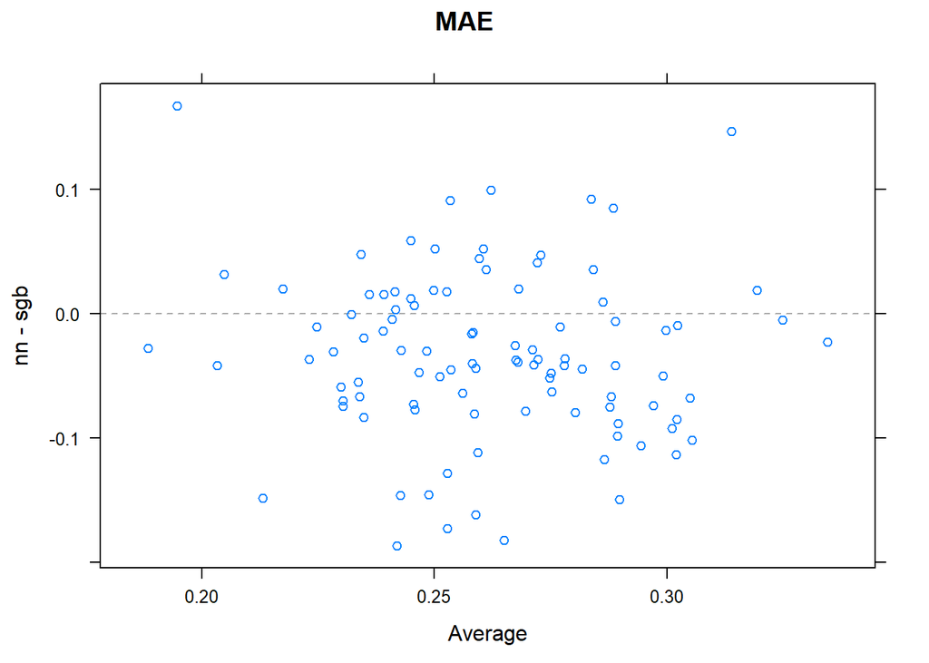

```r
xyplot(resamps.nn.sgb,what="BlandAltman")
```

```r
diffs.nn.sgb<-diff(resamps.nn.sgb)
summary(diffs.nn.sgb)
```

```
##
## Call:
## summary.diff.resamples(object = diffs.nn.sgb)
##
## p-value adjustment: bonferroni
## Upper diagonal: estimates of the difference
## Lower diagonal: p-value for H0: difference = 0
##
## MAE
##     nn        sgb
## nn            -0.03308
## sgb 3.192e-06
##
## RMSE
##     nn     sgb
## nn         0.001936
## sgb 0.8022
##
## Rsquared
##     nn     sgb
## nn         0.005528
## sgb 0.7911
```

## Neural Network - Random Forest

```r
resamps.nn.rf=resamples(list(nn=nnheartproc,rf=rfheart))
summary(resamps.nn.rf)
```

```
##
## Call:
## summary.resamples(object = resamps.nn.rf)
##
## Models: nn, rf
## Number of resamples: 100
##
## MAE
##         Min.   1st Qu.    Median      Mean   3rd Qu.      Max. NA's
## nn 0.1390773 0.2224683 0.2489029 0.2453692 0.2688941 0.3872968    0
## rf 0.1788264 0.2323399 0.2574746 0.2602595 0.2876510 0.3555556    0
##
## RMSE
##         Min.   1st Qu.    Median      Mean   3rd Qu.      Max. NA's
## nn 0.2222796 0.3227643 0.3601625 0.3572387 0.3885424 0.5204759    0
## rf 0.2510248 0.3163290 0.3444416 0.3477785 0.3790570 0.4418996    0
##
## Rsquared
##          Min.   1st Qu.    Median      Mean   3rd Qu.      Max. NA's
## nn 0.09257096 0.4087447 0.4893096 0.4950107 0.5790720 0.8326370    0
## rf 0.23668380 0.4154438 0.5350963 0.5214831 0.6176115 0.7874603    0
```

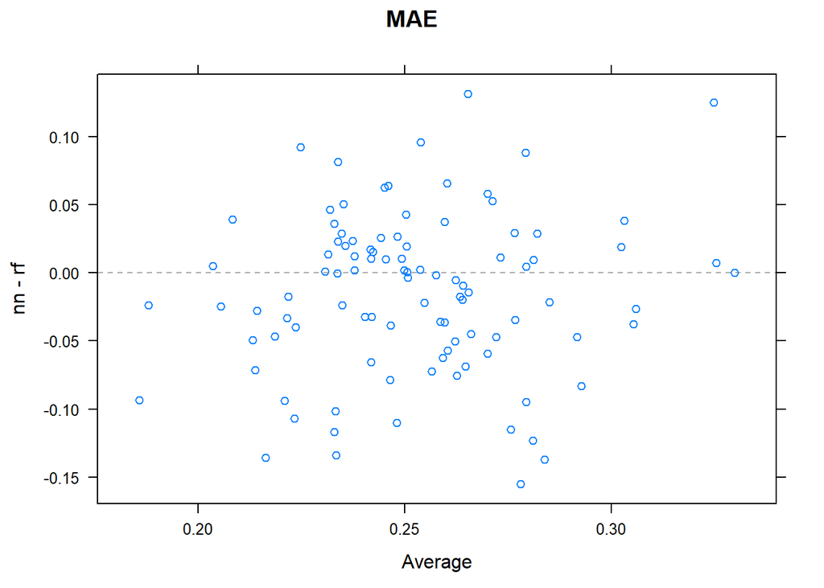

```r
xyplot(resamps.nn.rf,what="BlandAltman")
```

```r
diffs.nn.rf<-diff(resamps.nn.rf)
summary(diffs.nn.rf)
```

```
##
## Call:
## summary.diff.resamples(object = diffs.nn.rf)
##
## p-value adjustment: bonferroni
## Upper diagonal: estimates of the difference
## Lower diagonal: p-value for H0: difference = 0
##
## MAE
##    nn      rf
## nn         -0.01489
## rf 0.01283
##
## RMSE
##    nn     rf
## nn        0.00946
## rf 0.2147
##
## Rsquared
##    nn     rf
## nn        -0.02647
## rf 0.2052
```

## Stochastic Gradient Boosting - Random Forest

```r
resamps.sgb.rf=resamples(list(sgb=sgbheart,rf=rfheart))
summary(resamps.sgb.rf)
```

```
##
## Call:
## summary.resamples(object = resamps.sgb.rf)
##
## Models: sgb, rf
## Number of resamples: 100
##
## MAE
##          Min.   1st Qu.    Median      Mean   3rd Qu.      Max. NA's
## sgb 0.1108804 0.2432187 0.2803879 0.2784485 0.3111323 0.3644410    0
## rf  0.1788264 0.2323399 0.2574746 0.2602595 0.2876510 0.3555556    0
##
## RMSE
##          Min.   1st Qu.    Median      Mean   3rd Qu.      Max. NA's
## sgb 0.1601671 0.3193633 0.3552585 0.3553028 0.3918628 0.4519264    0
## rf  0.2510248 0.3163290 0.3444416 0.3477785 0.3790570 0.4418996    0
##
## Rsquared
##          Min.   1st Qu.    Median      Mean   3rd Qu.      Max. NA's
## sgb 0.2333212 0.3821634 0.4974993 0.4894827 0.5992779 0.8897388    0
## rf  0.2366838 0.4154438 0.5350963 0.5214831 0.6176115 0.7874603    0
```

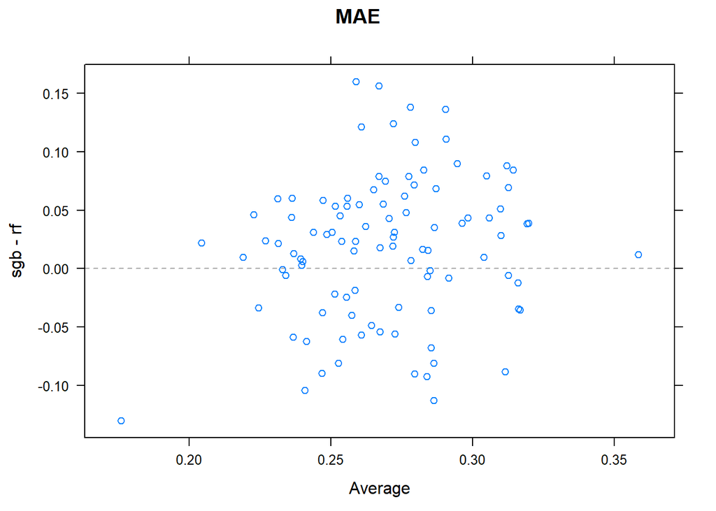

```r
xyplot(resamps.sgb.rf,what="BlandAltman")
```

```r
diffs.sgb.rf<-diff(resamps.sgb.rf)
summary(diffs.sgb.rf)
```

```
##
## Call:
## summary.diff.resamples(object = diffs.sgb.rf)
##
## p-value adjustment: bonferroni
## Upper diagonal: estimates of the difference
## Lower diagonal: p-value for H0: difference = 0
##
## MAE
##     sgb      rf
## sgb          0.01819
## rf  0.003638
##
## RMSE
##     sgb    rf
## sgb        0.007524
## rf  0.2621
##
## Rsquared
##     sgb     rf
## sgb         -0.032
## rf  0.09583
```

En todos los modelos se aprecia una gran dispersión cuando se compara el MAE.